# Proyecto Final_Econometria

2026-03-15

#Proyecto Final

Acciones y ETFs seleccionados XOM XLP XLE NVDA CL GLDM AGQ CVX SPY KO PEP TSLA

Estas acciones toman en cuenta el sector consumo, energetico, tecnologico y commodities y fueron las que se estuvieron utilizando a lo largo de las tareas.

```r
library(readxl)
```

```r
KO <- read_excel("KO.xlsx")
PEP  <- read_excel("PEP.xlsx")
XLP  <- read_excel("XLP.xlsx")
SPY  <- read_excel("SPY.xlsx")
GLDM <- read_excel("GLDM.xlsx")
NVDA <- read_excel("NVDA.xlsx")
XLE  <- read_excel("XLE.xlsx")
XOM  <- read_excel("XOM.xlsx")
CVX  <- read_excel("CVX.xlsx")
CL  <- read_excel("CL.xlsx")
TSLA  <- read_excel("TSLA.xlsx")
AGQ  <- read_excel("AGQ.xlsx")
```

Librerias

```r
library(dplyr)
```

```r
library(corrplot)
library(tidyverse)
library(car)
library(lmtest)
```

Como primer paso dejamos solo las columnas que necesitamos que son la de local date ya que esta engloba la fecha y hora y la columna de precio de cierre.

```r
KO2   <- KO   %>% select(datetime = `Local Date`, KO   = Close)
PEP2  <- PEP  %>% select(datetime = `Local Date`, PEP  = Close)
SPY2  <- SPY  %>% select(datetime = `Local Date`, SPY  = Close)
CL2   <- CL   %>% select(datetime = `Local Date`, CL   = Close)
XOM2  <- XOM  %>% select(datetime = `Local Date`, XOM  = Close)
XLP2  <- XLP  %>% select(datetime = `Local Date`, XLP  = Close)
XLE2  <- XLE  %>% select(datetime = `Local Date`, XLE  = Close)
NVDA2 <- NVDA %>% select(datetime = `Local Date`, NVDA = Close)
GLDM2 <- GLDM %>% select(datetime = `Local Date`, GLDM = Close)
AGQ2  <- AGQ  %>% select(datetime = `Local Date`, AGQ  = Close)
CVX2  <- CVX  %>% select(datetime = `Local Date`, CVX  = Close)
TSLA2 <- TSLA %>% select(datetime = `Local Date`, TSLA = Close)
```

Convertimos la columna datetime al formato POSIXct (fecha-hora real).

```r
KO2$datetime   <- as.POSIXct(KO2$datetime)
PEP2$datetime  <- as.POSIXct(PEP2$datetime)
SPY2$datetime  <- as.POSIXct(SPY2$datetime)
CL2$datetime   <- as.POSIXct(CL2$datetime)
XOM2$datetime  <- as.POSIXct(XOM2$datetime)
XLP2$datetime  <- as.POSIXct(XLP2$datetime)
XLE2$datetime  <- as.POSIXct(XLE2$datetime)
NVDA2$datetime <- as.POSIXct(NVDA2$datetime)
GLDM2$datetime <- as.POSIXct(GLDM2$datetime)
AGQ2$datetime  <- as.POSIXct(AGQ2$datetime)
CVX2$datetime  <- as.POSIXct(CVX2$datetime)
TSLA2$datetime <- as.POSIXct(TSLA2$datetime)
```

Unimos todas las variables independientes en un solo dataframe

```r
df_prices <- KO2   %>%
  inner_join(PEP2,  by = "datetime") %>%
  inner_join(SPY2,  by = "datetime") %>%
  inner_join(CL2,   by = "datetime") %>%
  inner_join(XOM2,  by = "datetime") %>%
  inner_join(XLP2,  by = "datetime") %>%
  inner_join(XLE2,  by = "datetime") %>%
  inner_join(NVDA2, by = "datetime") %>%
  inner_join(GLDM2, by = "datetime") %>%
  inner_join(AGQ2,  by = "datetime") %>%
  inner_join(CVX2,  by = "datetime") %>%
  inner_join(TSLA2, by = "datetime")
```

Convertimos los precios en rendimientos logaritmicos

```r
df_ret <- df_prices

df_ret$r_KO   <- log(df_ret$KO)   - log(dplyr::lag(df_ret$KO))
df_ret$r_PEP  <- log(df_ret$PEP)  - log(dplyr::lag(df_ret$PEP))
df_ret$r_SPY  <- log(df_ret$SPY)  - log(dplyr::lag(df_ret$SPY))
df_ret$r_CL   <- log(df_ret$CL)   - log(dplyr::lag(df_ret$CL))
df_ret$r_XOM  <- log(df_ret$XOM)  - log(dplyr::lag(df_ret$XOM))
df_ret$r_XLP  <- log(df_ret$XLP)  - log(dplyr::lag(df_ret$XLP))
df_ret$r_XLE  <- log(df_ret$XLE)  - log(dplyr::lag(df_ret$XLE))
df_ret$r_NVDA <- log(df_ret$NVDA) - log(dplyr::lag(df_ret$NVDA))
df_ret$r_GLDM <- log(df_ret$GLDM) - log(dplyr::lag(df_ret$GLDM))
df_ret$r_AGQ  <- log(df_ret$AGQ)  - log(dplyr::lag(df_ret$AGQ))
df_ret$r_CVX  <- log(df_ret$CVX)  - log(dplyr::lag(df_ret$CVX))
df_ret$r_TSLA <- log(df_ret$TSLA) - log(dplyr::lag(df_ret$TSLA))
```

```r
df_ret <- na.omit(df_ret)
```

Utlizamos el na.omit para eliminar celdas vacias

Construimos la correlación

```r
ret_cols <- df_ret %>%
  select(r_KO, r_PEP, r_SPY, r_CL, r_XOM,
         r_XLP, r_XLE, r_NVDA, r_GLDM, r_AGQ,
         r_CVX, r_TSLA) %>%
  na.omit()
```

Calcular matriz de correlación

```r
correlacion <- cor(ret_cols)
```

```r
print(round(correlacion, 2))
```

```
##         r_KO r_PEP r_SPY  r_CL r_XOM r_XLP r_XLE r_NVDA r_GLDM r_AGQ r_CVX
## r_KO    1.00  0.36 -0.05  0.14  0.07  0.23  0.04  -0.17  -0.03 -0.03  0.05
## r_PEP   0.36  1.00  0.00  0.14  0.11  0.25  0.13  -0.18  -0.04 -0.03  0.12
## r_SPY  -0.05  0.00  1.00 -0.02  0.06  0.04  0.16   0.56   0.19  0.23  0.10
## r_CL    0.14  0.14 -0.02  1.00  0.05  0.15  0.04  -0.08  -0.01 -0.02  0.22
## r_XOM   0.07  0.11  0.06  0.05  1.00 -0.04  0.65  -0.03   0.10  0.08  0.47
## r_XLP   0.23  0.25  0.04  0.15 -0.04  1.00  0.07  -0.08  -0.01 -0.01  0.07
## r_XLE   0.04  0.13  0.16  0.04  0.65  0.07  1.00   0.02   0.15  0.13  0.66
## r_NVDA -0.17 -0.18  0.56 -0.08 -0.03 -0.08  0.02   1.00   0.15  0.19  0.00
## r_GLDM -0.03 -0.04  0.19 -0.01  0.10 -0.01  0.15   0.15   1.00  0.77  0.11
## r_AGQ  -0.03 -0.03  0.23 -0.02  0.08 -0.01  0.13   0.19   0.77  1.00  0.10
## r_CVX   0.05  0.12  0.10  0.22  0.47  0.07  0.66   0.00   0.11  0.10  1.00
## r_TSLA -0.07 -0.03  0.27  0.00  0.00 -0.01  0.03   0.23   0.10  0.10  0.01
##        r_TSLA
## r_KO    -0.07
## r_PEP   -0.03
## r_SPY    0.27
## r_CL     0.00
## r_XOM    0.00
## r_XLP   -0.01
## r_XLE    0.03
## r_NVDA   0.23
## r_GLDM   0.10
## r_AGQ    0.10
## r_CVX    0.01
## r_TSLA   1.00
```

Gráfica

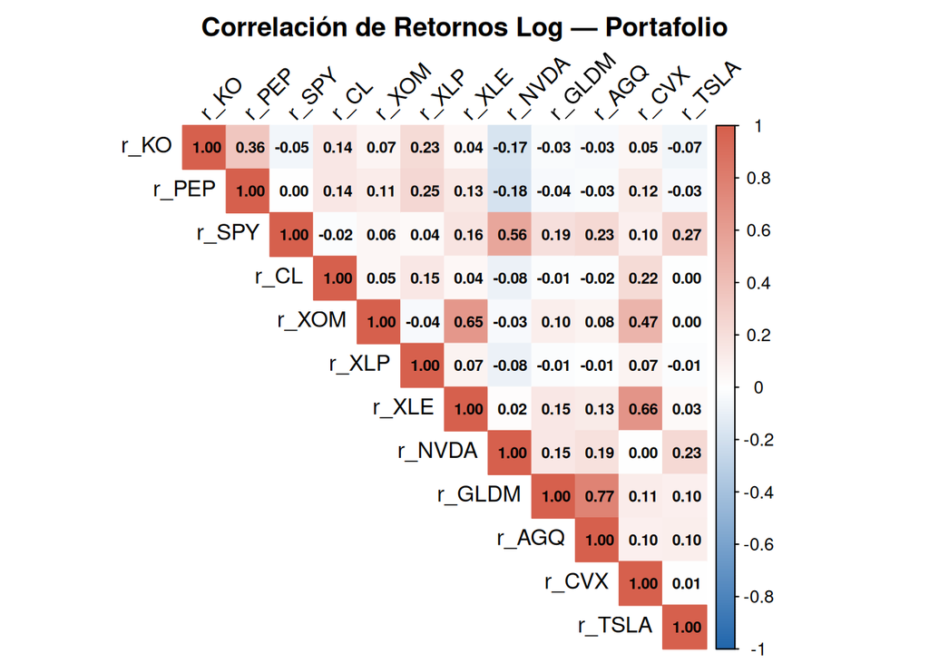

```r
corrplot(correlacion,
         method      = "color",
         type        = "upper",
         addCoef.col = "black",
         number.cex  = 0.7,
         tl.col      = "black",
         tl.srt      = 45,
         col         = colorRampPalette(c("#2166AC","white","#D6604D"))(200),
         title       = "Correlación de Retornos Log — Portafolio",
         mar         = c(0,0,2,0))
```

Al eliminar estos dos activos, el portafolio final queda de 10 acciones — KO, PEP, SPY, CL, XLP, XLE, NVDA, GLDM, CVX y TSLA — este mantiene una diversificación adecuada entre sectores, con correlaciones predominantemente bajas, lo que fortalece la validez estadística de los modelos de regresión que se realizaran a continuación.

#Modelos de Regresión lineal simple

Para los modelos se decidio seleccionar SPY como variable dependiente ya que este es el ETF que replica al S&P 500, es decir, representa el comportamiento del mercado en general. En una regresión lineal simple el objetivo es explicar cómo se mueve una acción en función de otra, y SPY es el benchmark mas utilizado.

Para las independientes serían los 9 tickers restantes

```r
independientes <- c("r_KO", "r_PEP", "r_CL", "r_XLP",
                    "r_XLE", "r_NVDA", "r_GLDM", "r_CVX", "r_TSLA")
```

```r
df_modelo <- df_ret %>%
  select(r_SPY, r_KO, r_PEP, r_CL, r_XLP,
         r_XLE, r_NVDA, r_GLDM, r_CVX, r_TSLA) %>%
  na.omit()
```

```r
SPY ~ KO
```

```
## SPY ~ KO
```

```r
reg_KO <- lm(r_SPY ~ r_KO, data = df_modelo)
summary(reg_KO)
```

```
##
## Call:
## lm(formula = r_SPY ~ r_KO, data = df_modelo)
##
## Residuals:
##       Min        1Q    Median        3Q       Max
## -0.039717 -0.000563 -0.000007  0.000530  0.038229
##
## Coefficients:
##               Estimate Std. Error t value Pr(>|t|)
## (Intercept) -1.660e-05  2.976e-05  -0.558  0.57707
## r_KO        -4.112e-02  1.308e-02  -3.144  0.00168 **
## ---
## Signif. codes:  0 '***' 0.001 '**' 0.01 '*' 0.05 '.' 0.1 ' ' 1
##
## Residual standard error: 0.001813 on 3712 degrees of freedom
## Multiple R-squared:  0.002656,   Adjusted R-squared:  0.002388
## F-statistic: 9.886 on 1 and 3712 DF,  p-value: 0.001678
```

SPY ~ KO (R2= 0.0027, Beta= -0.0411, p= 0.0017) Coca-Cola explica solo el 0.27% de la variación de SPY, con un beta negativo de -0.0411, lo que indica una ligera relación inversa. Esto tiene sentido ya que KO es un activo defensivo que tiende a comportarse diferente al mercado en momentos de volatilidad.

```r
SPY ~ PEP
```

```
## SPY ~ PEP
```

```r
reg_PEP <- lm(r_SPY ~ r_PEP, data = df_modelo)
summary(reg_PEP)
```

```
##
## Call:
## lm(formula = r_SPY ~ r_PEP, data = df_modelo)
##
## Residuals:
##       Min        1Q    Median        3Q       Max
## -0.039700 -0.000567 -0.000012  0.000522  0.038205
##
## Coefficients:
##               Estimate Std. Error t value Pr(>|t|)
## (Intercept) -1.504e-05  2.980e-05  -0.505    0.614
## r_PEP        2.155e-04  1.024e-02   0.021    0.983
##
## Residual standard error: 0.001816 on 3712 degrees of freedom
## Multiple R-squared:  1.193e-07,  Adjusted R-squared:  -0.0002693
## F-statistic: 0.0004427 on 1 and 3712 DF,  p-value: 0.9832
```

SPY ~ PEP (R2= 0.0000, Beta= 0.0002, p= 0.9832) PepsiCo es la variable con menor poder explicativo de todas, con un R2 de 0.00% y un p-valor de 0.9832, lo que significa que prácticamente no existe relación lineal entre PEP y SPY. PepsiCo es el activo más independiente del mercado en este portafolio.

```r
SPY ~ CL
```

```
## SPY ~ CL
```

```r
reg_CL <- lm(r_SPY ~ r_CL, data = df_modelo)
summary(reg_CL)
```

```
##
## Call:
## lm(formula = r_SPY ~ r_CL, data = df_modelo)
##
## Residuals:
##       Min        1Q    Median        3Q       Max
## -0.039666 -0.000570 -0.000009  0.000523  0.038175
##
## Coefficients:
##               Estimate Std. Error t value Pr(>|t|)
## (Intercept) -1.518e-05  2.979e-05  -0.509    0.610
## r_CL        -6.453e-03  5.943e-03  -1.086    0.278
##
## Residual standard error: 0.001816 on 3712 degrees of freedom
## Multiple R-squared:  0.0003176,  Adjusted R-squared:  4.824e-05
## F-statistic: 1.179 on 1 and 3712 DF,  p-value: 0.2776
```

SPY ~ CL (R2= 0.0003, Beta= -0.0065, p= 0.2776) Colgate-Palmolive no tiene ningún poder explicativo sobre SPY, con un R2 de apenas 0.03% y un p-valor de 0.2776, lo que indica que la relación no es estadísticamente significativa. CL se comporta de forma completamente independiente al mercado.

```r
SPY ~ XLP
```

```
## SPY ~ XLP
```

```r
reg_XLP <- lm(r_SPY ~ r_XLP, data = df_modelo)
summary(reg_XLP)
```

```
##
## Call:
## lm(formula = r_SPY ~ r_XLP, data = df_modelo)
##
## Residuals:
##       Min        1Q    Median        3Q       Max
## -0.039659 -0.000572 -0.000011  0.000528  0.038208
##
## Coefficients:
##               Estimate Std. Error t value Pr(>|t|)
## (Intercept) -1.462e-05  2.978e-05  -0.491   0.6236
## r_XLP        2.009e-02  9.070e-03   2.215   0.0268 *
## ---
## Signif. codes:  0 '***' 0.001 '**' 0.01 '*' 0.05 '.' 0.1 ' ' 1
##
## Residual standard error: 0.001815 on 3712 degrees of freedom
## Multiple R-squared:  0.001321,   Adjusted R-squared:  0.001051
## F-statistic: 4.908 on 1 and 3712 DF,  p-value: 0.02679
```

```r
SPY ~ XLE
```

```
## SPY ~ XLE
```

```r
reg_XLE <- lm(r_SPY ~ r_XLE, data = df_modelo)
summary(reg_XLE)
```

```
##
## Call:
## lm(formula = r_SPY ~ r_XLE, data = df_modelo)
##
## Residuals:
##       Min        1Q    Median        3Q       Max
## -0.039653 -0.000572 -0.000015  0.000507  0.038259
##
## Coefficients:
##               Estimate Std. Error t value Pr(>|t|)
## (Intercept) -7.921e-06  2.942e-05  -0.269    0.788
## r_XLE        1.086e-01  1.092e-02   9.952   <2e-16 ***
## ---
## Signif. codes:  0 '***' 0.001 '**' 0.01 '*' 0.05 '.' 0.1 ' ' 1
##
## Residual standard error: 0.001792 on 3712 degrees of freedom
## Multiple R-squared:  0.02599,    Adjusted R-squared:  0.02573
## F-statistic: 99.04 on 1 and 3712 DF,  p-value: < 2.2e-16
```

```r
SPY ~ NVDA
```

```
## SPY ~ NVDA
```

```r
reg_NVDA <- lm(r_SPY ~ r_NVDA, data = df_modelo)
summary(reg_NVDA)
```

```
##
## Call:
## lm(formula = r_SPY ~ r_NVDA, data = df_modelo)
##
## Residuals:
##       Min        1Q    Median        3Q       Max
## -0.039609 -0.000492 -0.000013  0.000478  0.038354
##
## Coefficients:
##               Estimate Std. Error t value Pr(>|t|)
## (Intercept) -1.339e-05  2.478e-05  -0.541    0.589
## r_NVDA       2.157e-01  5.299e-03  40.710   <2e-16 ***
## ---
## Signif. codes:  0 '***' 0.001 '**' 0.01 '*' 0.05 '.' 0.1 ' ' 1
##
## Residual standard error: 0.00151 on 3712 degrees of freedom
## Multiple R-squared:  0.3087, Adjusted R-squared:  0.3085
## F-statistic:  1657 on 1 and 3712 DF,  p-value: < 2.2e-16
```

SPY ~ NVDA (R2= 0.3087, Beta= 0.2157, p= 0.0000) NVDA es la variable que mejor explica el comportamiento de SPY, con un R2 de 0.3087, lo que significa que el 30.87% de la variación en los retornos del S&P 500 es explicada por NVIDIA. Por cada 1% que sube NVDA, SPY sube 0.2157%, siendo esta relación altamente significativa.

```r
SPY ~ GLDM
```

```
## SPY ~ GLDM
```

```r
reg_GLDM <- lm(r_SPY ~ r_GLDM, data = df_modelo)
summary(reg_GLDM)
```

```
##
## Call:
## lm(formula = r_SPY ~ r_GLDM, data = df_modelo)
##
## Residuals:
##       Min        1Q    Median        3Q       Max
## -0.039523 -0.000583 -0.000020  0.000516  0.038137
##
## Coefficients:
##              Estimate Std. Error t value Pr(>|t|)
## (Intercept) 4.742e-07  2.928e-05   0.016    0.987
## r_GLDM      1.044e-01  8.849e-03  11.803   <2e-16 ***
## ---
## Signif. codes:  0 '***' 0.001 '**' 0.01 '*' 0.05 '.' 0.1 ' ' 1
##
## Residual standard error: 0.001783 on 3712 degrees of freedom
## Multiple R-squared:  0.03617,    Adjusted R-squared:  0.03591
## F-statistic: 139.3 on 1 and 3712 DF,  p-value: < 2.2e-16
```

SPY ~ GLDM (R²= 0.0362, Beta= 0.1044, p= 0.0000) El oro explica apenas el 3.62% de la variación de SPY, lo que era esperado dado que los metales preciosos tienden a moverse de forma opuesta o independiente al mercado accionario. La relación es significativa pero débil.

```r
SPY ~ CVX
```

```
## SPY ~ CVX
```

```r
reg_CVX <- lm(r_SPY ~ r_CVX, data = df_modelo)
summary(reg_CVX)
```

```
##
## Call:
## lm(formula = r_SPY ~ r_CVX, data = df_modelo)
##
## Residuals:
##       Min        1Q    Median        3Q       Max
## -0.039660 -0.000571 -0.000014  0.000523  0.038248
##
## Coefficients:
##               Estimate Std. Error t value Pr(>|t|)
## (Intercept) -1.217e-05  2.966e-05  -0.410    0.682
## r_CVX        4.952e-02  8.307e-03   5.962 2.72e-09 ***
## ---
## Signif. codes:  0 '***' 0.001 '**' 0.01 '*' 0.05 '.' 0.1 ' ' 1
##
## Residual standard error: 0.001807 on 3712 degrees of freedom
## Multiple R-squared:  0.009485,   Adjusted R-squared:  0.009219
## F-statistic: 35.55 on 1 and 3712 DF,  p-value: 2.722e-09
```

SPY ~ CVX (R²= 0.0095, Beta= 0.0495, p= 0.0000) Chevron explica apenas el 0.95% de los retornos de SPY. A pesar de ser estadísticamente significativa, la relación es muy débil, lo que indica que los movimientos de CVX tienen poca influencia directa sobre el mercado general.

```r
SPY ~ TSLA
```

```
## SPY ~ TSLA
```

```r
reg_TSLA <- lm(r_SPY ~ r_TSLA, data = df_modelo)
summary(reg_TSLA)
```

```
##
## Call:
## lm(formula = r_SPY ~ r_TSLA, data = df_modelo)
##
## Residuals:
##       Min        1Q    Median        3Q       Max
## -0.039659 -0.000543 -0.000011  0.000492  0.038200
##
## Coefficients:
##               Estimate Std. Error t value Pr(>|t|)
## (Intercept) -1.351e-05  2.872e-05   -0.47    0.638
## r_TSLA       4.858e-02  2.887e-03   16.83   <2e-16 ***
## ---
## Signif. codes:  0 '***' 0.001 '**' 0.01 '*' 0.05 '.' 0.1 ' ' 1
##
## Residual standard error: 0.00175 on 3712 degrees of freedom
## Multiple R-squared:  0.07088,    Adjusted R-squared:  0.07063
## F-statistic: 283.2 on 1 and 3712 DF,  p-value: < 2.2e-16
```

SPY ~ TSLA (R2= 0.0709, Beta= 0.0486, p= 0.0000) Tesla explica el 7.09% de la variación en los retornos de SPY, con un beta de 0.0486. Aunque la relación es estadísticamente significativa, su poder explicativo es moderado, lo que confirma el comportamiento más independiente de TSLA respecto al mercado general.

```r
resumen <- data.frame(
  Variable = independientes,
  R2       = sapply(independientes, function(x)
               summary(lm(as.formula(paste("r_SPY ~", x)),
                          data = df_modelo))$r.squared),
  R2_adj   = sapply(independientes, function(x)
               summary(lm(as.formula(paste("r_SPY ~", x)),
                          data = df_modelo))$adj.r.squared),
  Beta     = sapply(independientes, function(x)
               coef(lm(as.formula(paste("r_SPY ~", x)),
                       data = df_modelo))[[2]]),
  P_valor  = sapply(independientes, function(x)
               summary(lm(as.formula(paste("r_SPY ~", x)),
                          data = df_modelo))$coefficients[2,4]),
  stringsAsFactors = FALSE
)

resumen <- resumen[order(-resumen$R2), ]
print(round(resumen[, -1], 4))
```

```
##            R2  R2_adj    Beta P_valor
## r_NVDA 0.3087  0.3085  0.2157  0.0000
## r_TSLA 0.0709  0.0706  0.0486  0.0000
## r_GLDM 0.0362  0.0359  0.1044  0.0000
## r_XLE  0.0260  0.0257  0.1086  0.0000
## r_CVX  0.0095  0.0092  0.0495  0.0000
## r_KO   0.0027  0.0024 -0.0411  0.0017
## r_XLP  0.0013  0.0011  0.0201  0.0268
## r_CL   0.0003  0.0000 -0.0065  0.2776
## r_PEP  0.0000 -0.0003  0.0002  0.9832
```

Realizamos una gráfica para cada regresión

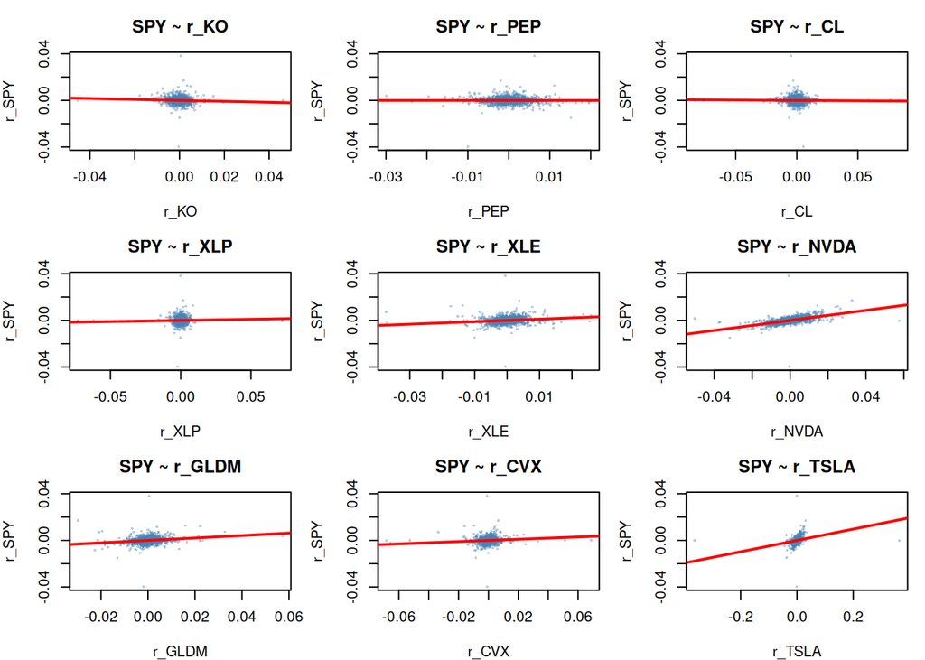

```r
par(mfrow = c(3, 3), mar = c(4, 4, 3, 1))

for (var in independientes) {
  plot(df_modelo[[var]], df_modelo$r_SPY,
       pch  = 16, cex = 0.4,
       col  = adjustcolor("steelblue", alpha.f = 0.4),
       xlab = var,
       ylab = "r_SPY",
       main = paste("SPY ~", var))
  abline(lm(as.formula(paste("r_SPY ~", var)), data = df_modelo),
         col = "red", lwd = 2)
}
```

```r
par(mfrow = c(1,1))
```

#Modelo Regresión Lineal Múltiple

```r
reg_multiple <- lm(r_SPY ~ r_KO + r_PEP + r_CL + r_XLP + r_XLE + r_NVDA + r_GLDM + r_CVX + r_TSLA, data = df_modelo)
summary(reg_multiple)
```

```
##
## Call:
## lm(formula = r_SPY ~ r_KO + r_PEP + r_CL + r_XLP + r_XLE + r_NVDA +
##     r_GLDM + r_CVX + r_TSLA, data = df_modelo)
##
## Residuals:
##       Min        1Q    Median        3Q       Max
## -0.038976 -0.000478 -0.000007  0.000454  0.038078
##
## Coefficients:
##               Estimate Std. Error t value Pr(>|t|)
## (Intercept)  8.431e-07  2.377e-05   0.035    0.972
## r_KO         6.563e-03  1.142e-02   0.575    0.566
## r_PEP        4.425e-02  9.043e-03   4.893 1.04e-06 ***
## r_CL         1.636e-03  5.009e-03   0.327    0.744
## r_XLP        3.054e-02  7.603e-03   4.016 6.02e-05 ***
## r_XLE        8.796e-02  1.197e-02   7.351 2.40e-13 ***
## r_NVDA       2.053e-01  5.387e-03  38.106  < 2e-16 ***
## r_GLDM       4.741e-02  7.356e-03   6.445 1.31e-10 ***
## r_CVX       -7.434e-03  9.173e-03  -0.810    0.418
## r_TSLA       2.443e-02  2.462e-03   9.921  < 2e-16 ***
## ---
## Signif. codes:  0 '***' 0.001 '**' 0.01 '*' 0.05 '.' 0.1 ' ' 1
##
## Residual standard error: 0.001446 on 3704 degrees of freedom
## Multiple R-squared:  0.3669, Adjusted R-squared:  0.3654
## F-statistic: 238.5 on 9 and 3704 DF,  p-value: < 2.2e-16
```

El modelo de regresión múltiple es estadísticamente significativo en su conjunto (F= 238.5, p< 2.2e-16), lo que indica que las 9 variables juntas explican de forma real el comportamiento de SPY. El R2 de 0.3669 significa que el modelo explica el 36.69% de la variación en los retornos del S&P 500, lo cual es un resultado bueno tomando en cuenta que son datos intradiarios de 30 minutos.

Ahora lo realizamos solo con las significativas para ver que tanto se ajusta el R2

```r
reg_significativo <- lm(r_SPY ~ r_NVDA + r_TSLA + r_GLDM + r_XLE + r_PEP + r_XLP,
                   data = df_modelo)
summary(reg_significativo)
```

```
##
## Call:
## lm(formula = r_SPY ~ r_NVDA + r_TSLA + r_GLDM + r_XLE + r_PEP +
##     r_XLP, data = df_modelo)
##
## Residuals:
##       Min        1Q    Median        3Q       Max
## -0.038948 -0.000479 -0.000006  0.000453  0.038067
##
## Coefficients:
##              Estimate Std. Error t value Pr(>|t|)
## (Intercept) 5.735e-07  2.376e-05   0.024    0.981
## r_NVDA      2.049e-01  5.351e-03  38.283  < 2e-16 ***
## r_TSLA      2.442e-02  2.459e-03   9.933  < 2e-16 ***
## r_GLDM      4.725e-02  7.351e-03   6.428 1.46e-10 ***
## r_XLE       8.159e-02  9.004e-03   9.061  < 2e-16 ***
## r_PEP       4.582e-02  8.606e-03   5.324 1.07e-07 ***
## r_XLP       3.135e-02  7.473e-03   4.195 2.80e-05 ***
## ---
## Signif. codes:  0 '***' 0.001 '**' 0.01 '*' 0.05 '.' 0.1 ' ' 1
##
## Residual standard error: 0.001446 on 3707 degrees of freedom
## Multiple R-squared:  0.3667, Adjusted R-squared:  0.3657
## F-statistic: 357.8 on 6 and 3707 DF,  p-value: < 2.2e-16
```

Al eliminar KO, CL y CVX, el R2 prácticamente no cambió (0.3667 vs 0.3669), pero el R2 ajustado mejoró de 0.3654 a 0.3657 y el F-statistic subió de 238.5 a 357.8, lo que confirma que el modelo reducido es más eficiente ya que explica casi lo mismo con menos variables.

#Detección de Errores

#Detección de Multicolinealidad

```r
vif(reg_multiple)
```

```
##     r_KO    r_PEP     r_CL    r_XLP    r_XLE   r_NVDA   r_GLDM    r_CVX
## 1.199443 1.228836 1.119085 1.106043 1.844197 1.125975 1.049733 1.903946
##   r_TSLA
## 1.065050
```

Todos los valores están entre 1.05 y 1.90, muy por debajo del umbral de 5. Esto significa que no existe multicolinealidad en el modelo ya que ninguna variable independiente está siendo explicada por las demás. El valor más alto es CVX con 1.90 y XLE con 1.84, lo cual tiene sentido por su relación en el sector energético, pero aún así está muy lejos de ser problemático.

#Pruebas de Heterocedasticidad Regresión Múltiple Modelo

```r
residuales_reg_multiple <- reg_multiple$residuals
```

Calculamos los residuales para el modelo

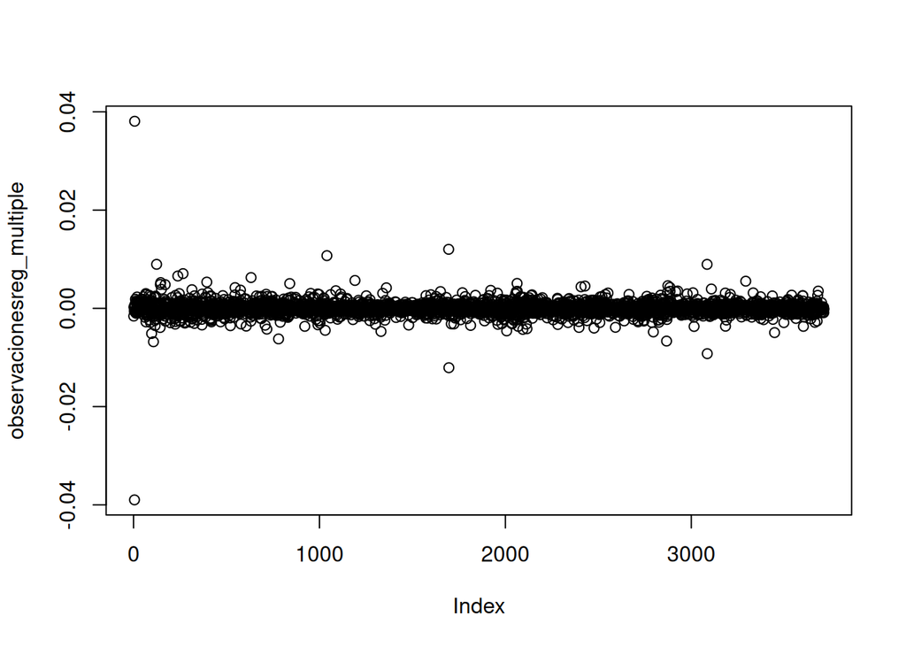

```r
observacionesreg_multiple <- c(residuals(reg_multiple))
plot(observacionesreg_multiple)
```

La gráfica muestra el comportamiento de los residuales a lo largo del modelo. Los residuales se distribuyen de forma aleatoria alrededor de cero, sin mostrar ningún patrón sistemático o tendencia a lo largo del tiempo, lo que es exactamente lo que se espera en un modelo de regresión especificado. La gran mayoría de los residuales se concentran en un rango muy estrecho entre -0.01 y 0.01, lo que indica que el modelo ajusta bien la mayor parte del tiempo. Sin embargo, se observan algunos valores atípicos (outliers)

```r
cuadres_reg_multiple <- observacionesreg_multiple^2
```

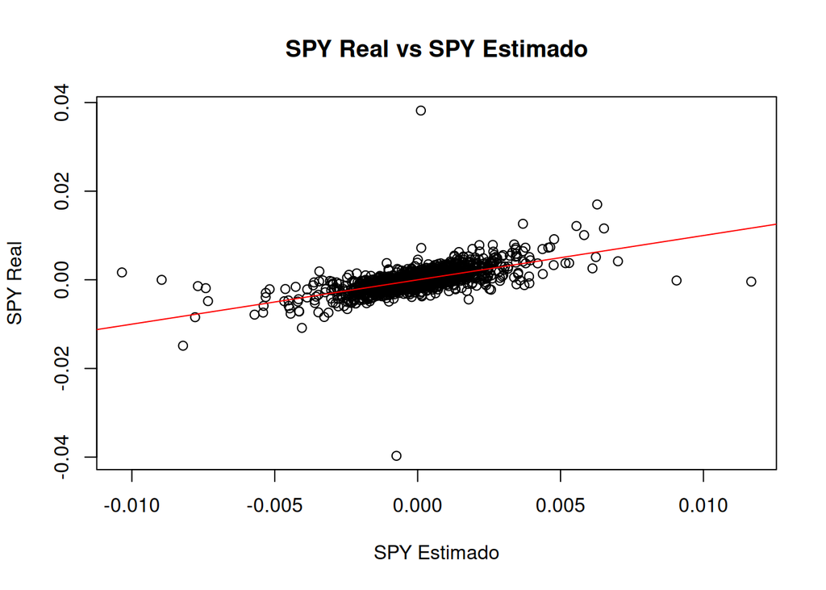

```r
plot(reg_multiple$fitted.values,
     reg_multiple$model$r_SPY,
     main = "SPY Real vs SPY Estimado",
     xlab = "SPY Estimado",
     ylab = "SPY Real")
abline(0, 1, col = "red")
```

La gráfica muestra una relación positiva clara entre los valores estimados por el modelo y los valores reales de SPY. La línea roja tiene pendiente positiva y la nube de puntos sigue esa dirección, lo que confirma que el modelo captura correctamente el sentido de los movimientos del mercado. La concentración de puntos alrededor del centro cerca de 0 es consistente con datos intradiarios de 30 minutos donde la mayoría de los retornos son pequeños.

```r
bptest(reg_multiple)
```

```
##
##  studentized Breusch-Pagan test
##
## data:  reg_multiple
## BP = 2.187, df = 9, p-value = 0.9882
```

Con un BP = 2.187 y p-valor = 0.9882, no se rechaza la hipótesis nula. Esto significa que la varianza de los residuales es constante y homogénea a lo largo de todas las observaciones, lo que implica que uno de los supuestos más importantes de la regresión lineal se cumple perfectamente.

```r
gqtest(reg_multiple, order.by = ~ r_SPY, data = df_modelo)
```

```
##
##  Goldfeld-Quandt test
##
## data:  reg_multiple
## GQ = 1.0654, df1 = 1847, df2 = 1847, p-value = 0.0867
## alternative hypothesis: variance increases from segment 1 to 2
```

Con un GQ = 1.0654 y p-valor = 0.0867, no se rechaza la hipótesis nula al nivel de significancia del 5%. Esto confirma que no existe heterocedasticidad en el modelo ya que la varianza de los errores es estable tanto para retornos pequeños como para retornos grandes de SPY. El p-valor de 0.0867 está por encima del0.05, aunque es relativamente cercano, lo que sugiere una ligera tendencia a que la varianza aumente del segmento 1 al 2, pero no lo suficiente como para ser estadísticamente significativa.

Este resultado es consistente con el Breusch-Pagan (p= 0.9882) y confirma que el supuesto de homocedasticidad se cumple en el modelo, validando la confiabilidad de los coeficientes estimados.

#Detección de autocorrelación

```r
dwtest(reg_multiple)
```

```
##
##  Durbin-Watson test
##
## data:  reg_multiple
## DW = 2.4426, p-value = 1
## alternative hypothesis: true autocorrelation is greater than 0
```

El estadístico DW cercano a 2 indica ausencia de autocorrelación positiva. Un valor de 2.4426 sugiere una ligera autocorrelación negativa (valores entre 2 y 4 apuntan en esa dirección), pero con p-valor = 1 no se rechaza la hipótesis nula. De acuerdo con esta prueba, no hay autocorrelación significativa en el modelo.

```r
bgtest(reg_multiple, order = 5)
```

```
##
##  Breusch-Godfrey test for serial correlation of order up to 5
##
## data:  reg_multiple
## LM test = 200.7, df = 5, p-value < 2.2e-16
```

Aquí el resultado es opuesto y más preocupante — con un p-valor prácticamente cero, sí se detecta autocorrelación serial hasta el orden 5. Esto significa que los residuales del periodo actual están correlacionados con los de los 5 periodos anteriores.

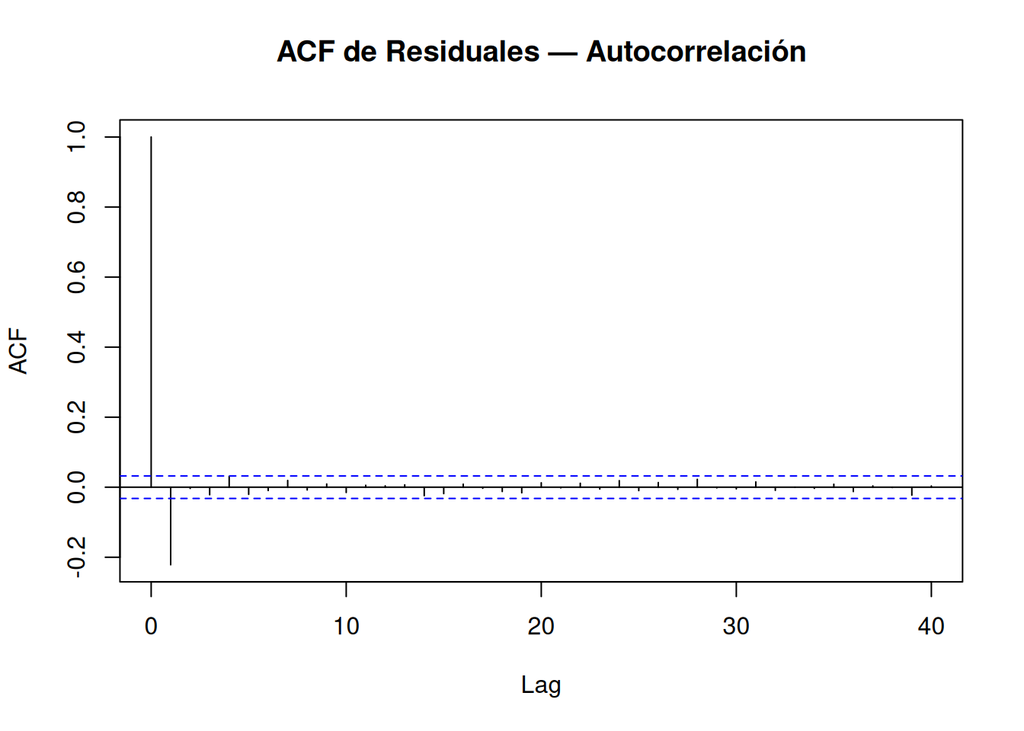

```r
acf(observacionesreg_multiple,
    main = "ACF de Residuales — Autocorrelación",
    lag.max = 40)
```

Existe autocorrelación de orden 1 en los residuales del modelo, lo cual es muy común en datos financieros intradiarios de 30 minutos — los retornos de un periodo están relacionados con el periodo inmediatamente anterior

#Data Panel

Para la construcción de este data panel se tomo en cuenta los reportes trimestrales de las empresas: KO, AAPLE,NVDA y WMT al tener su información disponible con un periodo del Q1 20216 al Q1 2026. Usando los datos de Revenue, EBITDA y Net Debt de cada empresa.

librerías necesarias

```r
library(readxl)
library(tidyverse)
library(plm)
library(plm)
```

```r
data_panel <- read_excel("/cloud/project/data_panel.xlsx")
data_panel$revenue  <- as.numeric(data_panel$revenue)
data_panel$ebitda   <- as.numeric(data_panel$ebitda)
data_panel$net_debt <- as.numeric(data_panel$net_debt)
```

```r
data_panel$revenue  <- as.numeric(data_panel$revenue)
data_panel$ebitda   <- as.numeric(data_panel$ebitda)
data_panel$net_debt <- as.numeric(data_panel$net_debt)

panel_df <- pdata.frame(data_panel, index = c("ticker", "trimestre"))

modelo_fe <- plm(revenue ~ ebitda + net_debt,
                 data  = panel_df,
                 model = "within")
summary(modelo_fe)
```

```
## Oneway (individual) effect Within Model
##
## Call:
## plm(formula = revenue ~ ebitda + net_debt, data = panel_df, model = "within")
##
## Unbalanced Panel: n = 4, T = 34-38, N = 143
##
## Residuals:
##       Min.    1st Qu.     Median    3rd Qu.       Max.
## -21966.387  -2751.713     26.526   1440.614  33203.540
##
## Coefficients:
##          Estimate Std. Error t-value  Pr(>|t|)
## ebitda   1.924260   0.138790 13.8645 < 2.2e-16 ***
## net_debt 0.121305   0.035518  3.4154 0.0008385 ***
## ---
## Signif. codes:  0 '***' 0.001 '**' 0.01 '*' 0.05 '.' 0.1 ' ' 1
##
## Total Sum of Squares:    3.1015e+10
## Residual Sum of Squares: 8.804e+09
## R-Squared:      0.71614
## Adj. R-Squared: 0.70578
## F-statistic: 172.814 on 2 and 137 DF, p-value: < 2.22e-16
```

El modelo es altamente significativo (F= 172.8, p< 2.22e-16) con un R2 de 0.7161, lo que significa que EBITDA y Net Debt explican el 71.6% de la variación en los ingresos de las 4 empresas — un ajuste excelente para un modelo de panel.

EBITDA (Beta= 1.924, p< 2.2e-16): es la variable más importante. Por cada millón de dólares que aumenta el EBITDA, el Revenue aumenta 1.92 millones, lo cual tiene todo el sentido económico ya que empresas más rentables operativamente generan más ingresos.

Net Debt (Beta= 0.121, p= 0.0008): también significativa. Por cada millón que aumenta la deuda neta, el Revenue sube 0.12 millones, sugiriendo que las empresas usan deuda para financiar crecimiento en ventas.

#Test de Hausman:

```r
modelo_re <- plm(revenue ~ ebitda + net_debt,
                 data  = panel_df,
                 model = "random")
summary(modelo_re)
```

```
## Oneway (individual) effect Random Effect Model
##    (Swamy-Arora's transformation)
##
## Call:
## plm(formula = revenue ~ ebitda + net_debt, data = panel_df, model = "random")
##
## Unbalanced Panel: n = 4, T = 34-38, N = 143
##
## Effects:
##                     var   std.dev share
## idiosyncratic 6.426e+07 8.016e+03 0.059
## individual    1.017e+09 3.189e+04 0.941
## theta:
##    Min. 1st Qu.  Median    Mean 3rd Qu.    Max.
##  0.9569  0.9569  0.9587  0.9580  0.9593  0.9593
##
## Residuals:
##     Min.  1st Qu.   Median     Mean  3rd Qu.     Max.
## -18556.2  -2791.3  -1149.8    -22.8     74.5  36582.3
##
## Coefficients:
##               Estimate Std. Error z-value  Pr(>|z|)
## (Intercept) 4.0667e+04 1.6394e+04  2.4807 0.0131123 *
## ebitda      1.9259e+00 1.4056e-01 13.7016 < 2.2e-16 ***
## net_debt    1.2354e-01 3.5869e-02  3.4441 0.0005729 ***
## ---
## Signif. codes:  0 '***' 0.001 '**' 0.01 '*' 0.05 '.' 0.1 ' ' 1
##
## Total Sum of Squares:    3.1817e+10
## Residual Sum of Squares: 9400100000
## R-Squared:      0.70456
## Adj. R-Squared: 0.70034
## Chisq: 333.641 on 2 DF, p-value: < 2.22e-16
```

```r
phtest(modelo_fe, modelo_re)
```

```
##
##  Hausman Test
##
## data:  revenue ~ ebitda + net_debt
## chisq = 0.21049, df = 2, p-value = 0.9001
## alternative hypothesis: one model is inconsistent
```

Modelo de Efectos Aleatorios

El modelo de efectos aleatorios también es altamente significativo (Chi2= 333.6, p< 2.22e-16) con un R2 de 0.7046, prácticamente igual al modelo de efectos fijos (0.7161). Ambas variables siguen siendo significativas con coeficientes muy similares — EBITDA con Beta= 1.926 y Net Debt con Beta= 0.124, confirmando la robustez del modelo. También debemos considerar el theta= 0.958, que es muy cercano a 1, lo que indica que la varianza entre empresas (individual= 0.941) domina sobre la varianza dentro de cada empresa (idiosincrática= 0.059). Esto significa que las diferencias entre NVDA, KO, WMT y AAPL son mucho más importantes que las variaciones dentro de cada empresa a lo largo del tiempo.

Test de Hausman

Con chi2= 0.21049 y p-valor= 0.9001, no se rechaza la hipótesis nula. Esto significa que se debe usar el modelo de efectos aleatorios, ya que ambos modelos son consistentes pero el de efectos aleatorios es más eficiente. En términos prácticos, las diferencias entre empresas no están correlacionadas con las variables explicativas del modelo.

Prueba F

```r
pFtest(modelo_fe, lm(revenue ~ ebitda + net_debt, data = data_panel))
```

```
##
##  F test for individual effects
##
## data:  revenue ~ ebitda + net_debt
## F = 1310.5, df1 = 3, df2 = 137, p-value < 2.2e-16
## alternative hypothesis: significant effects
```

Test de Breusch-Pagan

```r
plmtest(modelo_re, type = "bp")
```

```
##
##  Lagrange Multiplier Test - (Breusch-Pagan)
##
## data:  revenue ~ ebitda + net_debt
## chisq = 1328.4, df = 1, p-value < 2.2e-16
## alternative hypothesis: significant effects
```

Test de autocorrelación en el panel

```r
pbgtest(modelo_re)
```

```
##
##  Breusch-Godfrey/Wooldridge test for serial correlation in panel models
##
## data:  revenue ~ ebitda + net_debt
## chisq = 103.85, df = 34, p-value = 5.374e-09
## alternative hypothesis: serial correlation in idiosyncratic errors
```

Estos tres tests en conjunto confirman que el modelo de data panel con efectos aleatorios está correctamente especificado y es estadísticamente válido. La prueba F (F= 1310.5, p< 2.2e-16) demuestra que las diferencias entre NVDA, KO, WMT y AAPL son altamente significativas, lo que justifica el uso de un modelo de panel en lugar de una regresión simple. El test de Breusch-Pagan (chi2= 1328.4, p< 2.2e-16) confirma que los efectos aleatorios son necesarios y relevantes, validando la decisión del test de Hausman de preferir este modelo sobre el de efectos fijos.

Finalmente, el test de Breusch-Godfrey/Wooldridge (chi²= 103.85, p= 5.37e-09) detecta autocorrelación serial en los errores, lo cual es un comportamiento esperado en datos financieros trimestrales donde los ingresos de un periodo están naturalmente relacionados con los del periodo anterior. En conjunto, el modelo revenue ~ ebitda + net debt con efectos aleatorios es robusto, bien especificado y explica el 70.5% de la variación en los ingresos trimestrales de las cuatro empresas, siendo el EBITDA el determinante más importante del Revenue con un coeficiente de 1.926.

#Forecast Series de tiempo

Series de Tiempo - ARIMA + Forecast

Instalamos los paquetes de forecast y tseries

Librerías necesarias

```r
library(tidyverse)
library(forecast)
library(tseries)
```

Extraemos la serie de precios de SPY que necesitamos

```r
spy_precios <- df_prices %>%
  select(datetime, SPY) %>%
  na.omit() %>%
  arrange(datetime)
```

Convertir a objeto ts

```r
spy_ts <- ts(spy_precios$SPY, frequency = 13)  # 13 periodos por día
```

Graficamos sere original

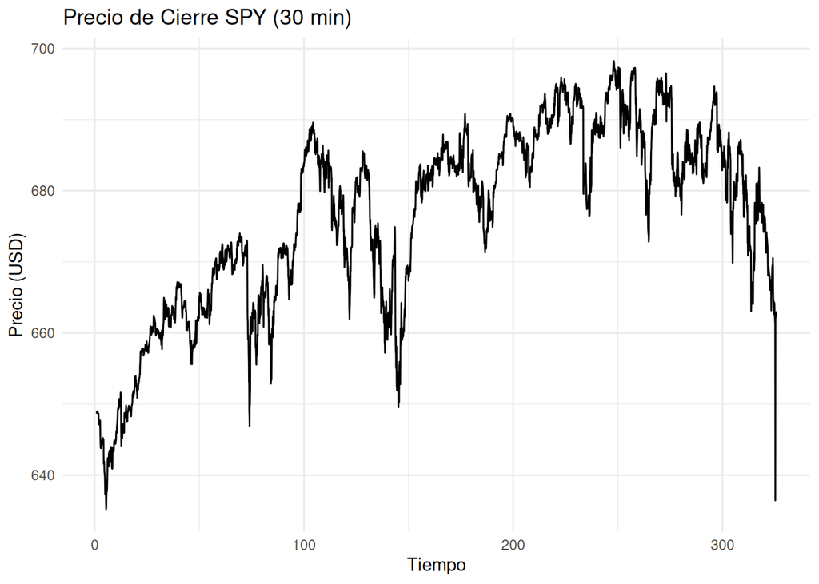

```r
autoplot(spy_ts) +
  labs(title = "Precio de Cierre SPY (30 min)",
       x = "Tiempo", y = "Precio (USD)") +
  theme_minimal()
```

Prueba de estacionariedad

```r
cat("\n--- TEST ADF (Augmented Dickey-Fuller) ---\n")
```

```
##
## --- TEST ADF (Augmented Dickey-Fuller) ---
```

```r
adf.test(spy_precios$SPY)
```

```
##
##  Augmented Dickey-Fuller Test
##
## data:  spy_precios$SPY
## Dickey-Fuller = -2.7873, Lag order = 16, p-value = 0.245
## alternative hypothesis: stationary
```

```r
cat("\n--- TEST KPSS ---\n")
```

```
##
## --- TEST KPSS ---
```

```r
kpss.test(spy_precios$SPY)
```

```
##
##  KPSS Test for Level Stationarity
##
## data:  spy_precios$SPY
## KPSS Level = 22.878, Truncation lag parameter = 10, p-value = 0.01
```

ADF (p-valor = 0.245): como p-valor > 0.05, la serie de precios de SPY NO es estacionaria — tiene tendencia y su media cambia con el tiempo. Hay que diferenciarla.

KPSS (p-valor = 0.01): como p-valor < 0.05, confirma lo mismo — la serie NO es estacionaria.

```r
spy_diff <- diff(spy_precios$SPY)
```

```r
cat("\n--- Test ASF despues de diferenciar ---\n")
```

```
##
## --- Test ASF despues de diferenciar ---
```

```r
adf.test(spy_diff)
```

```
##
##  Augmented Dickey-Fuller Test
##
## data:  spy_diff
## Dickey-Fuller = -16.771, Lag order = 16, p-value = 0.01
## alternative hypothesis: stationary
```

Graficamos serie diferenciada

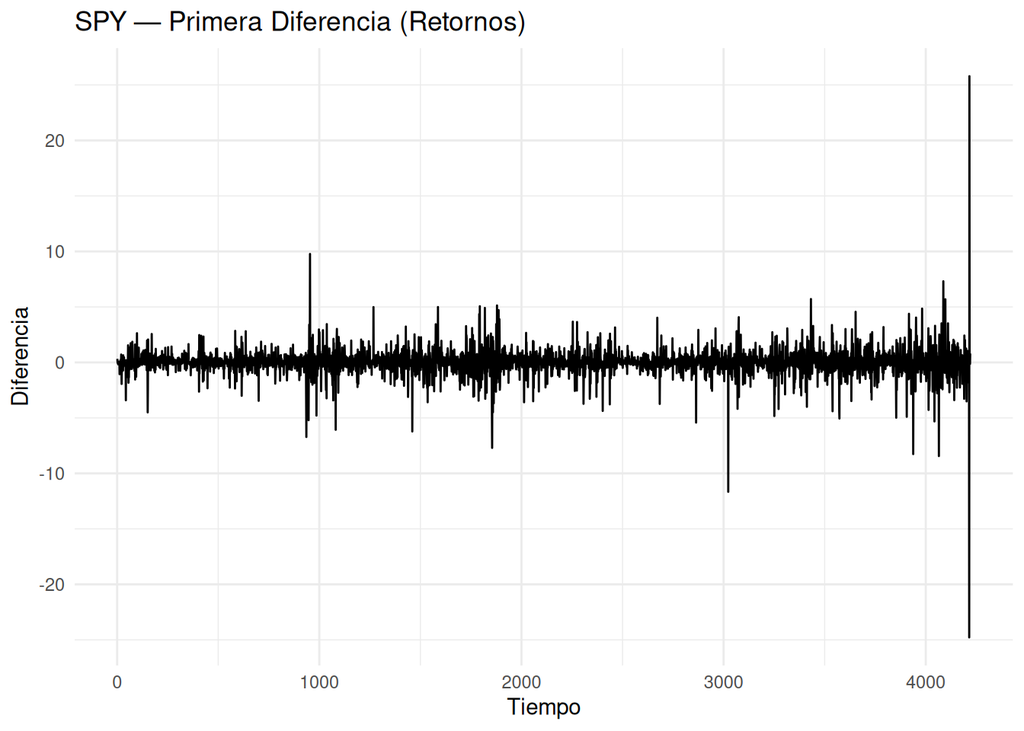

```r
autoplot(ts(spy_diff)) +
  labs(title = "SPY — Primera Diferencia (Retornos)",
       x = "Tiempo", y = "Diferencia") +
  theme_minimal()
```

ACF y PACF para identificar orden ARIMA

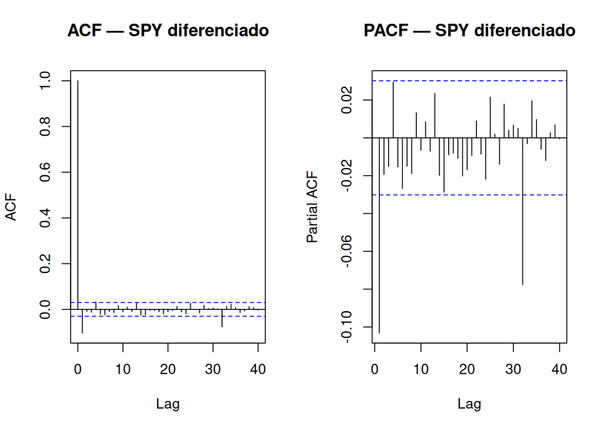

```r
par(mfrow = c(1, 2))
acf(spy_diff,  lag.max = 40, main = "ACF — SPY diferenciado")
pacf(spy_diff, lag.max = 40, main = "PACF — SPY diferenciado")
```

```r
par(mfrow = c(1, 1))
```

Modelo Arima Automatico

```r
cat("\n--- AJUSTANDO MODELO ARIMA AUTOMÁTICO ---\n")
```

```
##
## --- AJUSTANDO MODELO ARIMA AUTOMÁTICO ---
```

```r
modelo_arima <- auto.arima(spy_precios$SPY,
                           seasonal    = FALSE,
                           stepwise    = FALSE,
                           approximation = FALSE,
                           trace       = TRUE)
```

```
##
##  ARIMA(0,1,0)                    : 13298.78
##  ARIMA(0,1,0) with drift         : 13300.75
##  ARIMA(0,1,1)                    : 13254.24
##  ARIMA(0,1,1) with drift         : 13256.2
##  ARIMA(0,1,2)                    : 13255.84
##  ARIMA(0,1,2) with drift         : 13257.8
##  ARIMA(0,1,3)                    : 13257.64
##  ARIMA(0,1,3) with drift         : 13259.6
##  ARIMA(0,1,4)                    : 13256.62
##  ARIMA(0,1,4) with drift         : 13258.58
##  ARIMA(0,1,5)                    : 13255.03
##  ARIMA(0,1,5) with drift         : 13256.99
##  ARIMA(1,1,0)                    : 13255.63
##  ARIMA(1,1,0) with drift         : 13257.59
##  ARIMA(1,1,1)                    : 13255.81
##  ARIMA(1,1,1) with drift         : 13257.76
##  ARIMA(1,1,2)                    : 13257.86
##  ARIMA(1,1,2) with drift         : 13259.77
##  ARIMA(1,1,3)                    : 13257.79
##  ARIMA(1,1,3) with drift         : 13259.75
##  ARIMA(1,1,4)                    : 13257.35
##  ARIMA(1,1,4) with drift         : 13259.32
##  ARIMA(2,1,0)                    : 13256.07
##  ARIMA(2,1,0) with drift         : 13258.03
##  ARIMA(2,1,1)                    : 13257.82
##  ARIMA(2,1,1) with drift         : 13259.77
##  ARIMA(2,1,2)                    : 13258.67
##  ARIMA(2,1,2) with drift         : 13260.68
##  ARIMA(2,1,3)                    : 13257.25
##  ARIMA(2,1,3) with drift         : 13259.22
##  ARIMA(3,1,0)                    : 13257.12
##  ARIMA(3,1,0) with drift         : 13259.08
##  ARIMA(3,1,1)                    : 13257.1
##  ARIMA(3,1,1) with drift         : 13259.06
##  ARIMA(3,1,2)                    : 13245.49
##  ARIMA(3,1,2) with drift         : 13247.46
##  ARIMA(4,1,0)                    : 13255.45
##  ARIMA(4,1,0) with drift         : 13257.41
##  ARIMA(4,1,1)                    : 13257.04
##  ARIMA(4,1,1) with drift         : 13259
##  ARIMA(5,1,0)                    : 13256.28
##  ARIMA(5,1,0) with drift         : 13258.24
##
##
##
##  Best model: ARIMA(3,1,2)
```

```r
cat("\n--- MODELO SELECCIONADO ---\n")
```

```
##
## --- MODELO SELECCIONADO ---
```

```r
summary(modelo_arima)
```

```
## Series: spy_precios$SPY
## ARIMA(3,1,2)
##
## Coefficients:
##           ar1      ar2      ar3     ma1     ma2
##       -1.1267  -1.0798  -0.1165  1.0253  0.9728
## s.e.   0.0231   0.0196   0.0159  0.0180  0.0127
##
## sigma^2 = 1.349:  log likelihood = -6616.74
## AIC=13245.47   AICc=13245.49   BIC=13283.56
##
## Training set error measures:
##                       ME     RMSE       MAE          MPE       MAPE     MASE
## Training set 0.003876494 1.160562 0.6466784 0.0004262639 0.09581042 1.011358
##                      ACF1
## Training set -0.001853544
```

AR(3): el precio actual de SPY depende de los 3 periodos anteriores de 30 minutos I(1): se diferenció una vez para hacer la serie estacionaria — confirma lo que encontramos con ADF y KPSS MA(2): el modelo también considera los errores de predicción de los 2 periodos anteriores

Todos los coeficientes AR y MA son relevantes y sus errores estándar son pequeños relativos al coeficiente, lo que indica que están bien estimados. La combinación de ar1=-1.1267 y ma1=1.0253 casi opuestos es típica en series financieras y refleja la naturaleza de casi-ruido-blanco que vimos en el ACF.

En conclusión el modelo ARIMA(3,1,2) ajusta muy bien los precios de SPY con un error porcentual menor al 0.1%

Diagnostico del modelo

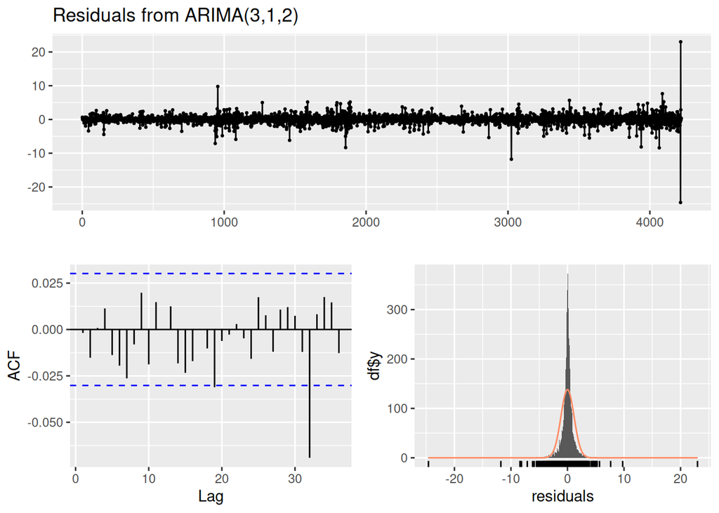

```
##
##  Ljung-Box test
##
## data:  Residuals from ARIMA(3,1,2)
## Q* = 10.321, df = 5, p-value = 0.06664
##
## Model df: 5.   Total lags used: 10
```

```r
par(mfrow = c(1, 1))
checkresiduals(modelo_arima)
```

Residuales: se distribuyen aleatoriamente alrededor de cero a lo largo de las 4,221 observaciones, sin ningún patrón sistemático. Se observan algunos valores atípicos puntuales que corresponden a momentos de alta volatilidad del mercado, pero son pocos y no afectan el modelo.

ACF de residuales: la mayoría de las barras están dentro de las bandas azules, aunque hay una barra significativa cerca del lag 32 que sale por debajo. Esto indica que el modelo captura bien la autocorrelación en general, con una ligera estructura residual en rezagos altos que es prácticamente irrelevante para el forecast de corto plazo.

Forecast

```r
forecast_spy <- forecast(modelo_arima, h = 40, level = c(80, 95))
```

Gráfica del forecast

[figure not shown]

```r
autoplot(forecast_spy) +
  labs(title = "Forecast SPY — Próximo Mes (40 periodos de 30 min)",
       x = "Tiempo", y = "Precio (USD)",
       caption = "Bandas: 80% y 95% de confianza") +
  theme_minimal()
```

Ver valores del forecast

```r
cat("\n--- Valores Forecast ---\n")
```

```
##
## --- Valores Forecast ---
```

```r
print(forecast_spy)
```

```
##      Point Forecast    Lo 80    Hi 80    Lo 95    Hi 95
## 4222       662.9836 661.4952 664.4720 660.7073 665.2599
## 4223       662.4688 660.4677 664.4699 659.4084 665.5292
## 4224       663.0271 660.6142 665.4400 659.3369 666.7173
## 4225       662.9617 660.2087 665.7148 658.7513 667.1722
## 4226       662.4925 659.4231 665.5619 657.7982 667.1867
## 4227       663.0267 659.6757 666.3778 657.9017 668.1518
## 4228       662.9391 659.3348 666.5435 657.4267 668.4515
## 4229       662.5156 658.6644 666.3668 656.6256 668.4056
## 4230       663.0251 658.9461 667.1041 656.7868 669.2634
## 4231       662.9186 658.6287 667.2085 656.3578 669.4795
## 4232       662.5378 658.0386 667.0370 655.6569 669.4187
## 4233       663.0225 658.3271 667.7179 655.8415 670.2034
## 4234       662.9000 658.0200 667.7801 655.4366 670.3635
## 4235       662.5590 657.4941 667.6239 654.8129 670.3051
```

[output cut: 26 more lines]

Métricas de precisión

```r
cat("\n--- Métricas de Precisión ---\n")
```

```
##
## --- Métricas de Precisión ---
```

```r
print(accuracy(modelo_arima))
```

```
##                       ME     RMSE       MAE          MPE       MAPE     MASE
## Training set 0.003876494 1.160562 0.6466784 0.0004262639 0.09581042 1.011358
##                      ACF1
## Training set -0.001853544
```

#GARCH

Instalamos los paquetes rugarch y FinTs

Acción seleccionada: SPY

Esto sirve modelar y predecir la volatilidad condicional no del precio sino que tan agresivos son los movimientos de SPY.

Librerías necesarias

```r
library(rugarch)
library(tidyverse)
library(FinTS)
```

Extraer retornos de SPY

```r
spy_ret <- df_ret %>%
  select(datetime, r_SPY) %>%
  na.omit() %>%
  arrange(datetime)
```

Graficar retornos

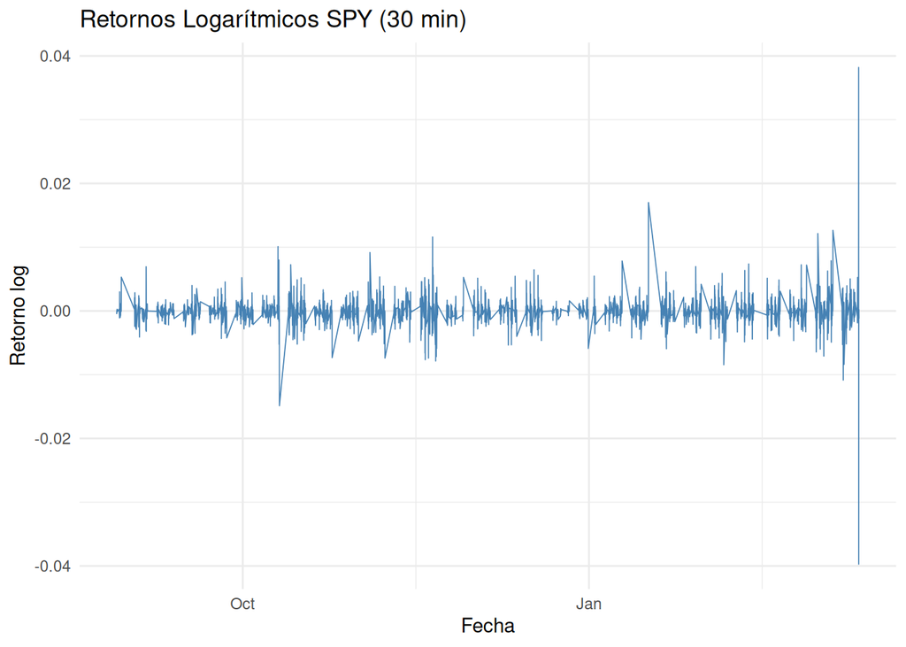

```r
ggplot(spy_ret, aes(x = datetime, y = r_SPY)) +
  geom_line(color = "steelblue", linewidth = 0.3) +
  labs(title = "Retornos Logarítmicos SPY (30 min)",
       x = "Fecha", y = "Retorno log") +
  theme_minimal()
```

Test ARCH

```r
cat("\n--- TEST ARCH (orden 5) ---\n")
```

```
##
## --- TEST ARCH (orden 5) ---
```

```r
ArchTest(spy_ret$r_SPY, lags = 5)
```

```
##
##  ARCH LM-test; Null hypothesis: no ARCH effects
##
## data:  spy_ret$r_SPY
## Chi-squared = 1204.7, df = 5, p-value < 2.2e-16
```

Con Chi2= 1204.7 y p-valor < 2.2e-16 se rechaza contundentemente la hipótesis nula de “no hay efectos ARCH”. Esto confirma que sí existe volatilidad agrupada en los retornos de SPY, los periodos de alta volatilidad tienden a ser seguidos por más alta volatilidad. Por tanto, este resultado es la justificación estadística perfecta para usar el modelo GARCH para modelar la volatilidad.

Especificar ARCH

```r
spec_garch <- ugarchspec(
  variance.model     = list(model = "sGARCH", garchOrder = c(1,1)),
  mean.model         = list(armaOrder = c(1,0), include.mean = TRUE),
  distribution.model = "std"
)
```

Ajustar modelo

```r
modelo_garch <- ugarchfit(spec = spec_garch, data = spy_ret$r_SPY, solver = "hybrid")
show(modelo_garch)
```

```
##
## *---------------------------------*
## *          GARCH Model Fit        *
## *---------------------------------*
##
## Conditional Variance Dynamics
## -----------------------------------
## GARCH Model  : sGARCH(1,1)
## Mean Model   : ARFIMA(1,0,0)
## Distribution : std
##
## Optimal Parameters
## ------------------------------------
##         Estimate  Std. Error  t value Pr(>|t|)
## mu     -0.000047    0.000013 -3.70119 0.000215
## ar1    -0.023315    0.015646 -1.49009 0.136202
## omega   0.000000    0.000000  0.63713 0.524038
## alpha1  0.346133    0.049599  6.97867 0.000000
## beta1   0.652867    0.040599 16.08079 0.000000
## shape   2.643317    0.082785 31.92977 0.000000
##
## Robust Standard Errors:
##         Estimate  Std. Error   t value Pr(>|t|)
## mu     -0.000047    0.000014 -3.409595 0.000651
## ar1    -0.023315    0.026546 -0.878260 0.379802
## omega   0.000000    0.000012  0.022786 0.981821
## alpha1  0.346133    0.930053  0.372165 0.709770
## beta1   0.652867    0.837683  0.779372 0.435760
## shape   2.643317    0.291022  9.082870 0.000000
##
## LogLikelihood : 19786.67
##
## Information Criteria
## ------------------------------------
##
## Akaike       -10.652
## Bayes        -10.642
## Shibata      -10.652
## Hannan-Quinn -10.648
##
```

[output cut: 43 more lines]

```
## Negative Sign Bias  0.3364 0.7366
## Positive Sign Bias  0.4022 0.6875
## Joint Effect        3.7505 0.2897
##
##
## Adjusted Pearson Goodness-of-Fit Test:
## ------------------------------------
##   group statistic p-value(g-1)
## 1    20     77.06    5.938e-09
## 2    30     88.55    6.070e-08
## 3    40     93.45    2.296e-06
## 4    50     97.93    4.143e-05
##
##
## Elapsed time : 0.3538589
```

Modelo ajustado GARCH con distribución t-student

alpha1 = 0.3461 (p< 0.0001): mide el impacto de shocks recientes en la volatilidad. Este valor de 0.35 indica que los movimientos bruscos del mercado tienen un efecto significativo e inmediato sobre la volatilidad futura de SPY.

beta1 = 0.6529 (p< 0.0001): mide la persistencia de la volatilidad. Un valor de 0.65 significa que la volatilidad de periodos anteriores sigue siendo relevante para explicar la volatilidad actual.

La suma alpha1 + beta1 = 0.999, muy cercana a 1, lo que indica que la volatilidad es altamente persistente — cuando el mercado se pone volátil, tarda en calmarse.

Usamos la t student ya que los retornos tienen colas pesadas, ocurren eventos extremos de manera más frecuente que los que predice uns distribución normal shape = 2.643 (p< 0.0001):

Graficar volatilidad condicional

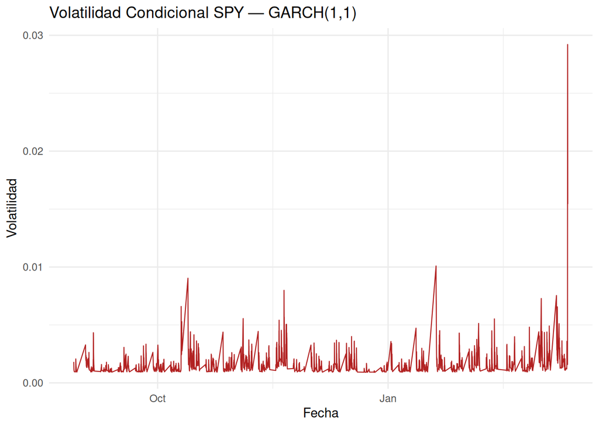

```r
spy_ret$volatilidad <- as.numeric(sigma(modelo_garch))
spy_ret$VaR_95      <- as.numeric(quantile(modelo_garch, probs = 0.05))

ggplot(spy_ret, aes(x = datetime, y = volatilidad)) +
  geom_line(color = "firebrick", linewidth = 0.4) +
  labs(title = "Volatilidad Condicional SPY — GARCH(1,1)",
       x = "Fecha", y = "Volatilidad") +
  theme_minimal()
```

La gráfica muestra la evolución de la volatilidad condicional de SPY a intervalos de 30 minutos desde agosto 2025 hasta marzo 2026. Durante la mayor parte del periodo la volatilidad se mantiene en un nivel base bajo de aproximadamente 0.001 a 0.003, con picos puntuales que coinciden con eventos de mercado relevantes que pudieran ser decisiones de la Fed, reportes de empleo o noticias macroeconómicas, entre otras. Lo más destacado de la gráfica es el pico extremo al final del periodo, el nivel más alto de toda la muestra y aproximadamente 10 veces el nivel base normal. Esto es consistente con la corrección que vimos en la gráfica de precios de SPY, donde el índice cayó significativamente en las últimas semanas.

Forecast de volatilidad 40 periodos

```r
forecast_garch <- ugarchforecast(modelo_garch, n.ahead = 40)
show(forecast_garch)
```

```
##
## *------------------------------------*
## *       GARCH Model Forecast         *
## *------------------------------------*
## Model: sGARCH
## Horizon: 40
## Roll Steps: 0
## Out of Sample: 0
##
## 0-roll forecast [T0=1980-03-03]:
##          Series   Sigma
## T+1  -1.951e-05 0.01250
## T+2  -4.725e-05 0.01251
## T+3  -4.660e-05 0.01251
## T+4  -4.662e-05 0.01252
## T+5  -4.662e-05 0.01252
## T+6  -4.662e-05 0.01253
## T+7  -4.662e-05 0.01253
## T+8  -4.662e-05 0.01254
## T+9  -4.662e-05 0.01254
## T+10 -4.662e-05 0.01255
## T+11 -4.662e-05 0.01255
## T+12 -4.662e-05 0.01256
## T+13 -4.662e-05 0.01256
## T+14 -4.662e-05 0.01257
## T+15 -4.662e-05 0.01257
## T+16 -4.662e-05 0.01258
## T+17 -4.662e-05 0.01258
## T+18 -4.662e-05 0.01259
## T+19 -4.662e-05 0.01259
## T+20 -4.662e-05 0.01260
## T+21 -4.662e-05 0.01260
## T+22 -4.662e-05 0.01261
## T+23 -4.662e-05 0.01261
## T+24 -4.662e-05 0.01262
## T+25 -4.662e-05 0.01262
## T+26 -4.662e-05 0.01263
## T+27 -4.662e-05 0.01263
## T+28 -4.662e-05 0.01264
## T+29 -4.662e-05 0.01264
## T+30 -4.662e-05 0.01265
## T+31 -4.662e-05 0.01265
## T+32 -4.662e-05 0.01266
## T+33 -4.662e-05 0.01266
## T+34 -4.662e-05 0.01267
## T+35 -4.662e-05 0.01267
## T+36 -4.662e-05 0.01268
## T+37 -4.662e-05 0.01268
## T+38 -4.662e-05 0.01269
## T+39 -4.662e-05 0.01269
## T+40 -4.662e-05 0.01270
```

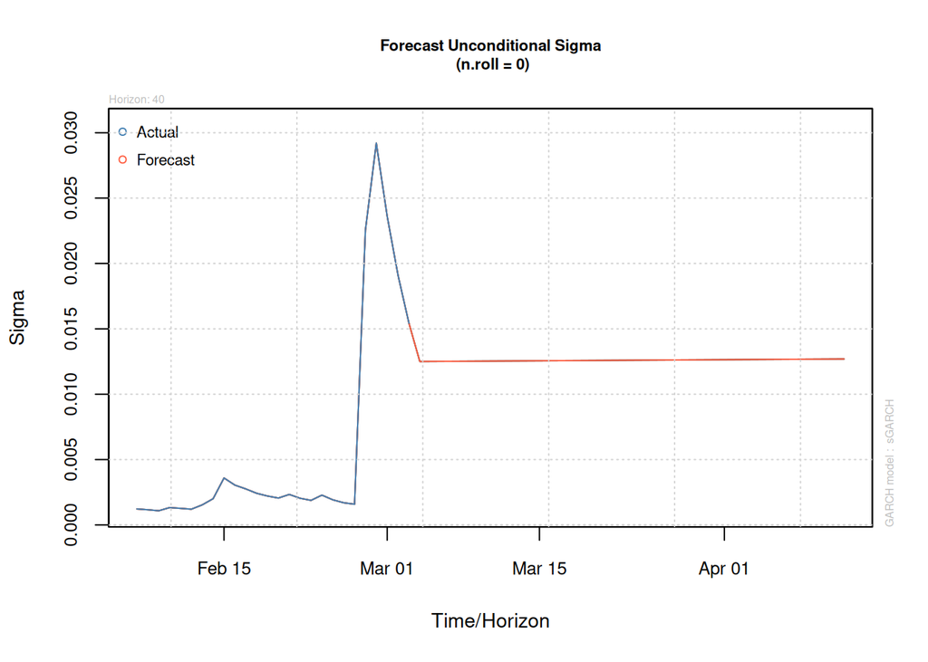

```r
plot(forecast_garch, which = 3)
```

VaR Dinamico

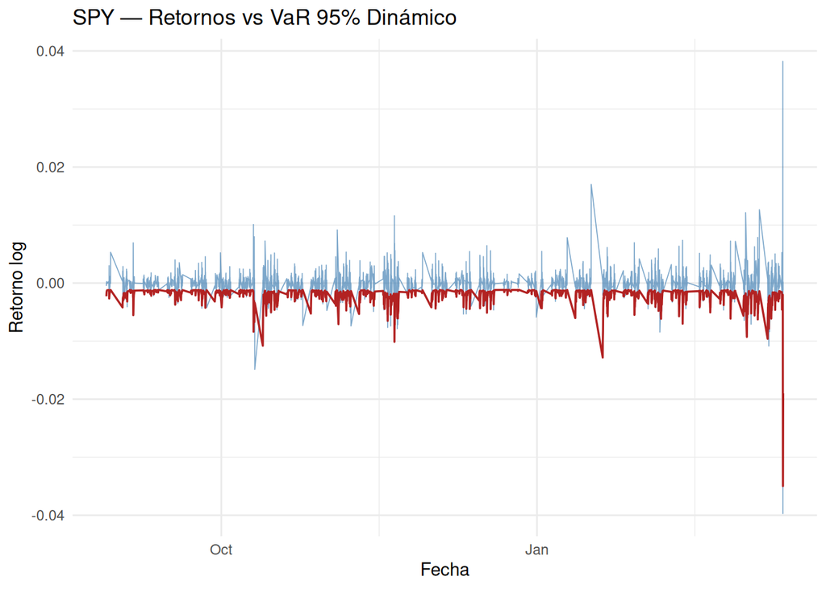

```r
ggplot(spy_ret, aes(x = datetime)) +
  geom_line(aes(y = r_SPY),  color = "steelblue", linewidth = 0.3, alpha = 0.7) +
  geom_line(aes(y = VaR_95), color = "firebrick", linewidth = 0.6) +
  labs(title = "SPY — Retornos vs VaR 95% Dinámico",
       x = "Fecha", y = "Retorno log") +
  theme_minimal()
```

La línea azul son los retornos reales de SPY cada 30 minutos esta sube y baja constantemente alrededor de cero. La línea roja es el VaR 95% dinámico, es decir la pérdida máxima esperada en cada periodo. Se dice que es dinámica porque cambia con la volatilidad del mercado.El modelo GARCH(1,1) modela y predice exitosamente tanto la volatilidad condicional como el riesgo de pérdida de SPY, esto nos sirve para identificar en tiempo real cuando el mercado entra en regímenes de alta volatilidad como el observado en marzo 2026.